# Time dependent AUC with survival data _ correct5-3

Hwang Seong-Yun

2022 4 29

# Loading packages

```r
library(survival)
library(timeROC)
library(timereg)
library(ggplot2)
library(reshape)
library(plyr)
library(tidyverse)
library(coxed)
library(gridExtra)
library(survsim)
```

# Generating simulation data from Cox Regression Model with time dependent covariates

## Background

- reference : https://dx.doi.org/10.21037/atm.2018.02.12 (Title : Time-varying covariates and coefficients in Cox regression models)

`--` Function `simple.surv.sim()` in package `survsim`

```r
simple.surv.sim(n, foltime, dist.ev, anc.ev, beta0.ev, dist.cens="weibull",
anc.cens, beta0.cens, z=NULL, beta=NA, x=NA)
```

`-` Arguments

- n : integer value indicating the desired size of the cohort to be simulated.
- foltime : real number that indicates the maximum time of follow-up of the simulated cohort.
- dist.ev : time to event distributions, with possible values weibull for the Weibull distribution, lnorm for the log-normal distribution and llogistic for the log-logistic distribution.
- anc.ev : ancillary parameter for the time to event distribution.
- beta0.ev : β_0 parameter for the time to event distribution.
- dist.cens : string indicating the time to censoring distributions, with possible values weibull for the Weibull distribution, lnorm for the log-normal distribution, llogistic for the log-logistic distribution and unif for the uniform distribution. If no distribution is introduced, the time to censoring is assumed to follow a Weibull distribution.
- anc.cens : real number containing the ancillary parameter for the time to censoring distribution or the maximum in case of uniform distributed time to censoring.
- beta0.cens : real number containing the β_0 parameter for the time to censoring distribution or the minimum in case of uniform distributed time to censoring.
- z : vector with three elements that contains information relative to a random effect used in order to introduce individual heterogeneity. The first element indicates the distribution: “unif” states for a uniform distribution, “gamma” states for a gamma distribution, “exp” states for an exponential distribution, “weibull” states for a Weibull distribution and “invgauss” states for an inverse gaussian distribution. The second and third elements indicates the minimum and maximum in the case of a uniform distribution (both must be positive) and the parameters in the case of the rest of distributions. Notice that that just one parameter is needed in the case of exponential distribution. Its default value is NULL, indicating that no individual heterogeneity is introduced.
- beta : list of elements indicating the effect of the corresponding covariate. The number of vectors in beta must match the number of covariates. Its default value is NA, indicating that no covariates are included.
- x : list of vectors indicating the distribution and parameters of any covariate that the user needs to introduce in the simulated cohort. The possible distributions are “normal” for normal distribution, “unif” for uniform distribution and “bern” for Bernoulli distribution. Its default value is NA, indicating that no covariates are included. The number of vectors in x must match the number of vectors in beta. Each vector in x must contain the name of the distribution and the parameter(s), which are: the probability of success in the case of a Bernoulli distribution; the mean and the variance in the case of a normal distribution; and the minimum and maximum in the case of a uniform distribution.

`-` Value

- nid : an integer number that identifies the subject.
- status : logical value indicating if the corresponding event has been suffered or not.
- start : time at which the follow-up time begins for each event.
- stop : time at which the follow-up time ends for each event.
- z : Individual heterogeneity generated according to the specified distribution.
- x : value of each covariate randomly generated for each subject in the cohort.

## Generating simulation data

### Generates a data frame containing two time-fixed variables named “grp” (abbreviated from group) and “age”

```r
N <- 100 # number of patients
set.seed(123)
df.tf <- simple.surv.sim(# baseline time fixed
   n=N, foltime=500,
   dist.ev=c('llogistic'),
   anc.ev=c(0.68), beta0.ev=c(5.8),
   anc.cens=1.2,
   beta0.cens=7.4,
   z=list(c("unif", 0.8, 1.2)),
   beta=list(c(-0.4),c(0)),
   x=list(c("bern", 0.5),
   c("normal", 70, 13)))
names(df.tf)[c(1,6,7)] <- c("id","grp","age")
head(df.tf,20)
```

```
##    id status start      stop         z grp      age
## 1   1      1     0  48.12817 1.1532070   0 80.40721
## 2   2      0     0 121.43904 0.9826459   1 86.11345
## 3   3      1     0  30.65770 1.1599300   1 72.38007
## 4   4      0     0 500.00000 1.0771214   0 91.97240
## 5   5      1     0  69.54117 1.0376568   1 77.13826
## 6   6      1     0 233.05486 1.1181870   1 86.83192
## 7   7      1     0 156.28825 0.8926503   1 59.80303
## 8   8      1     0 257.55453 0.8555224   0 65.64613
## 9   9      1     0  84.25968 0.9768800   0 83.91794
## 10 10      1     0 172.01674 1.1013231   1 59.35930
## 11 11      1     0 175.01728 0.9097535   1 52.95021
## 12 12      1     0 309.59798 0.9759327   1 81.52757
## 13 13      1     0 268.64023 0.8880476   1 28.04480
## 14 14      0     0 500.00000 1.0672222   0 54.13334
## 15 15      1     0 133.20145 1.1572204   0 67.86890
## 16 16      1     0 129.61382 1.0627033   0 75.11821
## 17 17      1     0 138.61371 1.0046022   1 52.85381
## 18 18      0     0 218.81522 1.1561401   0 91.96834
## 19 19      0     0 500.00000 0.9204916   0 56.36332
## 20 20      1     0 201.12761 1.1816365   1 56.08911
```

### Generates a time varying covariate named crp (C-reactive protein) which is assumed to have a normal distribution with a mean of 100 and a standard deviation of 40 and skewed

```r
set.seed(123)
nft <- sample(1:10,N,replace=T) # number of follow up time points
crp <- round(abs(rnorm(sum(nft)+N,mean=100,sd=40)),1)
time <- NA
id <- NA
i <- 0
for (n in nft) {
    i <- i+1
    time.n <- sample(1:500,n)
    time.n <- c(0,sort(time.n))
    time <- c(time,time.n)
    id.n <- rep(i,n+1)
    id <- c(id,id.n)
}
df.td <- cbind(data.frame(id,time)[-1,],crp)
head(df.td,20)
```

```
##    id time   crp
## 2   1    0 115.4
## 3   1  207  85.2
## 4   1  253 125.8
## 5   1  373  91.2
## 6   2    0 113.3
## 7   2  110 143.9
## 8   2  403 117.4
## 9   2  466  87.0
## 10  3    0 146.0
## 11  3   52 139.7
## 12  3  165 121.9
## 13  3  191 109.5
## 14  3  256  74.9
## 15  3  274 154.4
## 16  3  323  76.0
## 17  3  363 187.5
## 18  3  382 161.3
## 19  3  406  90.6
## 20  3  435  58.9
## 21  4    0  71.6
```

### Merging data frames with tmerge() function

`--` Function `tmerge()` in package ‘survival’

```r
tmerge(data1, data2,  id,..., tstart, tstop, options)
```

`-` Arguments

- data1 : the primary data set, to which new variables and/or observation will be added
- data2 : second data set in which all the other arguments will be found
- id : subject identifier
- … : operations that add new variables or intervals, see below
- tstart : optional variable to define the valid time range for each subject, only used on an initial call
- tstop : optional variable to define the valid time range for each subject, only used on an initial call
- options : a list of options. Valid ones are idname, tstartname, tstopname, delay, na.rm, and tdcstart. See the explanation below.

```r
df <- tmerge(df.tf,df.tf,id=id,endpt=event(stop,status))
head(df,20)
```

```
##    id status start      stop         z grp      age tstart     tstop endpt
## 1   1      1     0  48.12817 1.1532070   0 80.40721      0  48.12817     1
## 2   2      0     0 121.43904 0.9826459   1 86.11345      0 121.43904     0
## 3   3      1     0  30.65770 1.1599300   1 72.38007      0  30.65770     1
## 4   4      0     0 500.00000 1.0771214   0 91.97240      0 500.00000     0
## 5   5      1     0  69.54117 1.0376568   1 77.13826      0  69.54117     1
## 6   6      1     0 233.05486 1.1181870   1 86.83192      0 233.05486     1
## 7   7      1     0 156.28825 0.8926503   1 59.80303      0 156.28825     1
## 8   8      1     0 257.55453 0.8555224   0 65.64613      0 257.55453     1
## 9   9      1     0  84.25968 0.9768800   0 83.91794      0  84.25968     1
## 10 10      1     0 172.01674 1.1013231   1 59.35930      0 172.01674     1
## 11 11      1     0 175.01728 0.9097535   1 52.95021      0 175.01728     1
## 12 12      1     0 309.59798 0.9759327   1 81.52757      0 309.59798     1
## 13 13      1     0 268.64023 0.8880476   1 28.04480      0 268.64023     1
## 14 14      0     0 500.00000 1.0672222   0 54.13334      0 500.00000     0
## 15 15      1     0 133.20145 1.1572204   0 67.86890      0 133.20145     1
## 16 16      1     0 129.61382 1.0627033   0 75.11821      0 129.61382     1
## 17 17      1     0 138.61371 1.0046022   1 52.85381      0 138.61371     1
## 18 18      0     0 218.81522 1.1561401   0 91.96834      0 218.81522     0
## 19 19      0     0 500.00000 0.9204916   0 56.36332      0 500.00000     0
## 20 20      1     0 201.12761 1.1816365   1 56.08911      0 201.12761     1
```

```r
df <- tmerge(df,df.td,id=id,crp=tdc(time,crp))
head(df,20)
```

```
##    id status start      stop         z grp      age tstart     tstop endpt
## 1   1      1     0  48.12817 1.1532070   0 80.40721      0  48.12817     1
## 2   2      0     0 121.43904 0.9826459   1 86.11345      0 110.00000     0
## 3   2      0     0 121.43904 0.9826459   1 86.11345    110 121.43904     0
## 4   3      1     0  30.65770 1.1599300   1 72.38007      0  30.65770     1
## 5   4      0     0 500.00000 1.0771214   0 91.97240      0  18.00000     0
## 6   4      0     0 500.00000 1.0771214   0 91.97240     18 366.00000     0
## 7   4      0     0 500.00000 1.0771214   0 91.97240    366 500.00000     0
## 8   5      1     0  69.54117 1.0376568   1 77.13826      0  69.54117     1
## 9   6      1     0 233.05486 1.1181870   1 86.83192      0 233.05486     1
## 10  7      1     0 156.28825 0.8926503   1 59.80303      0  18.00000     0
## 11  7      1     0 156.28825 0.8926503   1 59.80303     18 156.28825     1
## 12  8      1     0 257.55453 0.8555224   0 65.64613      0  35.00000     0
## 13  8      1     0 257.55453 0.8555224   0 65.64613     35  54.00000     0
## 14  8      1     0 257.55453 0.8555224   0 65.64613     54 198.00000     0
```

[output cut: 27 more lines]

### All covariates

```r
fit.tdc1 <- coxph(Surv(tstart,tstop,endpt)~grp+age+crp+cluster(id),data=df)
summary(fit.tdc1)
```

```
## Call:
## coxph(formula = Surv(tstart, tstop, endpt) ~ grp + age + crp,
##     data = df, cluster = id)
##
##   n= 395, number of events= 67
##
##         coef exp(coef) se(coef) robust se     z Pr(>|z|)
## grp 0.499588  1.648043 0.252177  0.256273 1.949   0.0512 .
## age 0.002662  1.002666 0.008062  0.007432 0.358   0.7202
## crp 0.005474  1.005489 0.003322  0.003113 1.758   0.0787 .
## ---
## Signif. codes:  0 '***' 0.001 '**' 0.01 '*' 0.05 '.' 0.1 ' ' 1
##
##     exp(coef) exp(-coef) lower .95 upper .95
## grp     1.648     0.6068    0.9973     2.723
## age     1.003     0.9973    0.9882     1.017
## crp     1.005     0.9945    0.9994     1.012
##
## Concordance= 0.578  (se = 0.041 )
## Likelihood ratio test= 6.82  on 3 df,   p=0.08
## Wald test            = 6.4  on 3 df,   p=0.09
## Score (logrank) test = 6.78  on 3 df,   p=0.08,   Robust = 6.42  p=0.09
##
##   (Note: the likelihood ratio and score tests assume independence of
##      observations within a cluster, the Wald and robust score tests do not).
```

```r
risk.tdc1 <- predict(object=fit.tdc1, newdata=df, type="risk") # risk score
df$risk.tdc1 <- risk.tdc1
ROC.risk.tdc1 <- timeROC(T=df$tstop,
                         delta=df$endpt,marker=df$risk.tdc1,
                         cause=1,weighting="marginal",
                         times=df$tstop)
ROC.risk.tdc1
```

```
## Time-dependent-Roc curve estimated using IPCW  (n=395, without competing risks).
##       Cases Survivors Censored AUC (%)
## t=4       0       394        1      NA
## t=77     14       295       86   63.35
## t=163    36       196      163   58.22
## t=294    54        99      242   65.43
## t=500    67         0      328      NA
##
## Method used for estimating IPCW:marginal
##
## Total computation time : 0.13  secs.
```

### Except time-dependent covariates

```r
fit.tdc2 <- coxph(Surv(tstart,tstop,endpt)~grp+age+cluster(id),data=df)
summary(fit.tdc2)
```

```
## Call:
## coxph(formula = Surv(tstart, tstop, endpt) ~ grp + age, data = df,
##     cluster = id)
##
##   n= 395, number of events= 67
##
##          coef exp(coef)  se(coef) robust se     z Pr(>|z|)
## grp 0.5048255 1.6566964 0.2523690 0.2545010 1.984   0.0473 *
## age 0.0007706 1.0007709 0.0080531 0.0071967 0.107   0.9147
## ---
## Signif. codes:  0 '***' 0.001 '**' 0.01 '*' 0.05 '.' 0.1 ' ' 1
##
##     exp(coef) exp(-coef) lower .95 upper .95
## grp     1.657     0.6036    1.0060     2.728
## age     1.001     0.9992    0.9868     1.015
##
## Concordance= 0.552  (se = 0.042 )
## Likelihood ratio test= 4.11  on 2 df,   p=0.1
## Wald test            = 3.94  on 2 df,   p=0.1
## Score (logrank) test = 4.08  on 2 df,   p=0.1,   Robust = 4.23  p=0.1
##
##   (Note: the likelihood ratio and score tests assume independence of
##      observations within a cluster, the Wald and robust score tests do not).
```

```r
risk.tdc2 <- predict(object=fit.tdc2, newdata=df, type="risk") # risk score
df$risk.tdc2 <- risk.tdc2
ROC.risk.tdc2 <- timeROC(T=df$tstop,
                         delta=df$endpt,marker=df$risk.tdc2,
                         cause=1,weighting="marginal",
                         times=df$tstop)
ROC.risk.tdc2
```

```
## Time-dependent-Roc curve estimated using IPCW  (n=395, without competing risks).
##       Cases Survivors Censored AUC (%)
## t=4       0       394        1      NA
## t=77     14       295       86   62.27
## t=163    36       196      163   56.14
## t=294    54        99      242   60.23
## t=500    67         0      328      NA
##
## Method used for estimating IPCW:marginal
##
## Total computation time : 0.07  secs.
```

### Except time-fixed covariates

```r
fit.tdc3 <- coxph(Surv(tstart,tstop,endpt)~crp+cluster(id),data=df)
summary(fit.tdc3)
```

```
## Call:
## coxph(formula = Surv(tstart, tstop, endpt) ~ crp, data = df,
##     cluster = id)
##
##   n= 395, number of events= 67
##
##         coef exp(coef) se(coef) robust se     z Pr(>|z|)
## crp 0.005384  1.005399 0.003245  0.003009 1.789   0.0736 .
## ---
## Signif. codes:  0 '***' 0.001 '**' 0.01 '*' 0.05 '.' 0.1 ' ' 1
##
##     exp(coef) exp(-coef) lower .95 upper .95
## crp     1.005     0.9946    0.9995     1.011
##
## Concordance= 0.564  (se = 0.039 )
## Likelihood ratio test= 2.73  on 1 df,   p=0.1
## Wald test            = 3.2  on 1 df,   p=0.07
## Score (logrank) test = 2.75  on 1 df,   p=0.1,   Robust = 2.99  p=0.08
##
##   (Note: the likelihood ratio and score tests assume independence of
##      observations within a cluster, the Wald and robust score tests do not).
```

```r
risk.tdc3 <- predict(object=fit.tdc3, newdata=df, type="risk") # risk score
df$risk.tdc3 <- risk.tdc3
ROC.risk.tdc3 <- timeROC(T=df$tstop,
                         delta=df$endpt,marker=df$risk.tdc3,
                         cause=1,weighting="marginal",
                         times=df$tstop)
ROC.risk.tdc3
```

```
## Time-dependent-Roc curve estimated using IPCW  (n=395, without competing risks).
##       Cases Survivors Censored AUC (%)
## t=4       0       394        1      NA
## t=77     14       295       86   62.84
## t=163    36       196      163   57.57
## t=294    54        99      242   58.33
## t=500    67         0      328      NA
##
## Method used for estimating IPCW:marginal
##
## Total computation time : 0.1  secs.
```

#### Make AUC data

```r
# uncensored
uncensored.density1 <- density(df$tstop[df$endpt==1])
data1_1 <- data.frame(time=uncensored.density1[["x"]],
                    density=uncensored.density1[["y"]])
data1_1$density.adjusted <- (max(na.omit(ROC.risk.tdc3[["AUC"]]))-min(na.omit(ROC.risk.tdc3[["AUC"]])))*(uncensored.density1[["y"]]-min(uncensored.density1[["y"]]))/(max(uncensored.density1[["y"]])-min(uncensored.density1[["y"]]))+min(na.omit(ROC.risk.tdc3[["AUC"]]))

# censored
censored.density1 <- density(df$tstop[df$endpt==0])
data1_2 <- data.frame(time=censored.density1[["x"]],
                    density=censored.density1[["y"]])
data1_2$density.adjusted <- (max(na.omit(ROC.risk.tdc3[["AUC"]]))-min(na.omit(ROC.risk.tdc3[["AUC"]])))*(censored.density1[["y"]]-min(censored.density1[["y"]]))/(max(censored.density1[["y"]])-min(censored.density1[["y"]]))+min(na.omit(ROC.risk.tdc3[["AUC"]]))

res1 <- data.frame(time=ROC.risk.tdc3[["times"]],
                    fit.tdc1=ROC.risk.tdc1[["AUC"]],
                    fit.tdc2=ROC.risk.tdc2[["AUC"]],
                    fit.tdc3=ROC.risk.tdc3[["AUC"]])
res1 <- melt(data = res1,
                   id.vars = "time",
                   measure.vars = c("fit.tdc1","fit.tdc2","fit.tdc3"))
```

#### Time dependent AUC plot with ggplot2 (fit.tdc1,fit.tdc2,fit.tdc3)

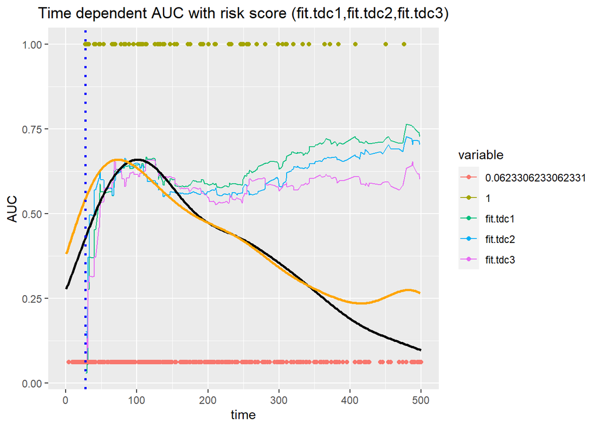

```r
df$censor1 <- ifelse(df$endpt==1,
                    1,min(na.omit(ROC.risk.tdc3[["AUC"]])))
ggplot() +
  geom_line(data=res1, aes(x=time, y=value,
                            group=variable, color=variable)) +
  geom_point(data=df, aes(x=tstop, y=censor1, color=as.factor(censor1))) +
  geom_line(data=data1_1, aes(x=time, y=density.adjusted),
            size=1, colour='black') +
  geom_line(data=data1_2, aes(x=time, y=density.adjusted),
            size=1, colour='orange') +
  scale_x_continuous(limits = c(0, max(df$tstop))) +
  geom_vline(xintercept = min(df$tstop[df$endpt==1]),
             linetype="dotted", color = "blue", size=1) +
  ggtitle("Time dependent AUC with risk score (fit.tdc1,fit.tdc2,fit.tdc3)") +
  xlab("time") + ylab("AUC") +
  theme(plot.title = element_text(hjust = 0.5))
```

#### Mean value of Time dependent AUC (“fit.tdc1”,“fit.tdc2”,“fit.tdc3”)

```r
mean(ROC.risk.tdc1[["AUC"]],na.rm=TRUE)
```

```
## [1] 0.6003613
```

```r
mean(ROC.risk.tdc2[["AUC"]],na.rm=TRUE)
```

```
## [1] 0.5841768
```

```r
mean(ROC.risk.tdc3[["AUC"]],na.rm=TRUE)
```

```
## [1] 0.5622691
```